# Simulation Results

Danielle McCool

13-4-2021

## 0.1 Short gaps

Linear interpolation is hypothesized to work quite well in bridging short time gaps. This represents a reduction in the density of the points, but when the gaps do not exceed time intervals of 5-10 minutes, the total level of acceptable sparsity could be much higher before it impacts travel metrics of interest.

Analysis steps proceeded in this order:

1. For each 24 hour period
2. For each $q$
   1. Sample without replacement the number of intervals to be removed
   2. Replace gaps in the data longer than 3 minutes and larger than 80 meters by linear interpolation between the preceding and subsequent point at one second intervals.
   3. Apply the stop detection algorithm
      1. Mark as a candidate stop all points for which all points in the subsequent 180 seconds are within 80 meters.
      2. Mark as being within a stop all points falling within the previous requirement
      3. Determine state switches (move -> stop, stop -> move, stop -> stop)
      4. Merge stops
         - If a stop adjacent to another stop is not more than 100 meters distant from the mean center of the previous stop, merge all locations within this stop to the previous stop
         - If two stops are separated by a move state whose summed distance between all points is less than 300 meters, merge into the previous stop.
      5. Repeat until no further changes are made.
      6. Calculate aggregate measures on both states
   4. If there is at least one move state
      - Apply top down time ratio algorithm to divide move states into segments
      - Calculate aggregate measures on move states
   5. Apply top down time ratio algorithm to divide data set into segments and calculate aggregate measures
   6. Repeat step 2 20 times

The data with induced missingness were compared to the complete data set in order to evaluate which metrics were impacted. Table 1 shows the decrease in moved distance and number of stops with increasing sparsity. At 30% sparsity, the mean distance retained is almost 90%, and the median distance retained is 93%. Only as sparsity levels exceed 60% does the median distance lost reach 20%. Similarly, we see that linear interpolation doesn’t reduce the median number of stops until sparsity reaches 50%. In fact, these short gaps become problematic only when they become long gaps, as two or more adjacent short gaps merge into one.

Table 1: Selected MCAR Short Gap Results (Median)

| q | Delta Moved Distance (Km) | Delta Radius of Gyration | Delta Number of Stops |
| --- | --- | --- | --- |
| 0.1 | -0.4 (-1.2%) | 1.2 (5%) | 0 (0%) |
| 0.2 | -1.1 (-3.8%) | 2.8 (11.3%) | 0 (0%) |
| 0.3 | -1.8 (-6.9%) | 4.7 (18.9%) | 0 (0%) |
| 0.4 | -2.6 (-10.2%) | 7.1 (28.1%) | 0 (0%) |
| 0.5 | -3.8 (-14.2%) | 10 (40.2%) | -1 (-9.1%) |
| 0.6 | -4.9 (-18.4%) | 13.7 (55.3%) | -1 (-16.7%) |
| 0.7 | -6.5 (-24%) | 19.1 (77.5%) | -1 (-20%) |
| 0.8 | -8.5 (-31.7%) | 26.9 (111.4%) | -2 (-30%) |
| 0.9 | -11.9 (-47.7%) | 39.8 (173.1%) | -2 (-43.7%) |

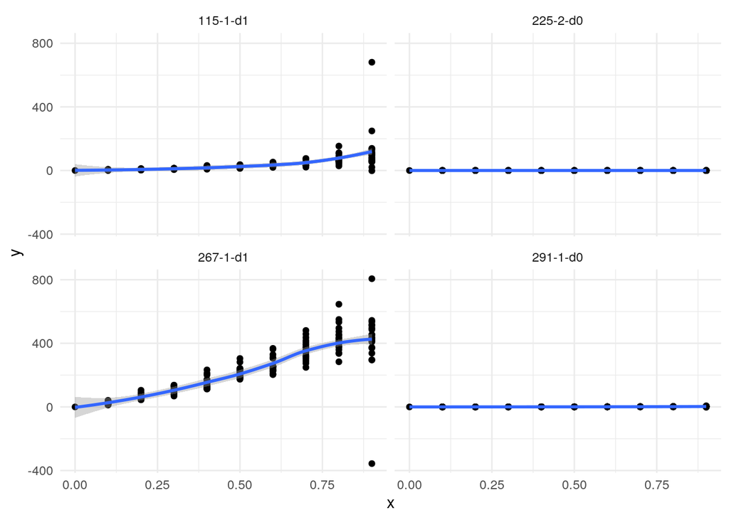

## 0.2 Long gaps

Analysis steps proceeded in this order:

1. For each 24 hour period
2. For each of 20 iterations
3. Select a random time point from the 24 hours
   1. Remove 10 percent of the remaining data following from this time point
   2. Replace gaps in the data longer than 3 minutes and larger than 80 meters by linear interpolation between the preceding and subsequent point at one second intervals.
   3. Apply the stop detection algorithm
      1. Mark as a candidate stop all points for which all points in the subsequent 180 seconds are within 80 meters.
      2. Mark as being within a stop all points falling within the previous requirement
      3. Determine state switches (move -> stop, stop -> move, stop -> stop)
      4. Merge stops
         - If a stop adjacent to another stop is not more than 100 meters distant from the mean center of the previous stop, merge all locations within this stop to the previous stop
         - If two stops are separated by a move state whose summed distance between all points is less than 300 meters, merge into the previous stop.
      5. Repeat until no further changes are made.
      6. Calculate aggregate measures on both states
   4. If there is at least one move state
      - Apply top down time ratio algorithm to divide move states into segments
      - Calculate aggregate measures on move states
   5. Apply top down time ratio algorithm to divide data set into segments and calculate aggregate measures
   6. Return to Step 3A

Table 2: Selected MCAR Long Gap Results (Median)

| q | Delta Moved Distance (Km) | Delta Radius of Gyration | Delta Number of Stops |
| --- | --- | --- | --- |
| 0.1 | 0 (0%) | 1.2 (2.5%) | 0 (0%) |
| 0.2 | 0 (0%) | 2.4 (5.3%) | 0 (0%) |
| 0.3 | -2.3 (-8.7%) | 3.4 (8.8%) | 0 (0%) |
| 0.4 | -6.5 (-25.3%) | 4.2 (14.4%) | -1 (-25%) |
| 0.5 | -11 (-46%) | 3.1 (14.6%) | -2 (-33.3%) |
| 0.6 | -17 (-52.3%) | 1.3 (9.2%) | -2 (-50%) |
| 0.7 | -24.3 (-68.3%) | -0.2 (-12.7%) | -3 (-54.5%) |
| 0.8 | -31.9 (-97.3%) | -7.8 (-65%) | -4 (-66.7%) |
| 0.9 | -38 (-100%) | -25.9 (-96.2%) | -4 (-75%) |

Radius of gyration and urbanicity

## 0.4 Covariates allow varying cutoff points

Finally, we sought to establish a set of covariates that could impact this relationship. This could allow for extending the boundaries of what we consider the maximum acceptable gap time.

### 0.4.1 Time

Of central importance was the investigation of time as a metric. Both Android and iOS operating systems employ mechanisms for reducing device activity during times of lesser activity levels, contributing to long gaps during nights that are unlikely to contain travel behavior.

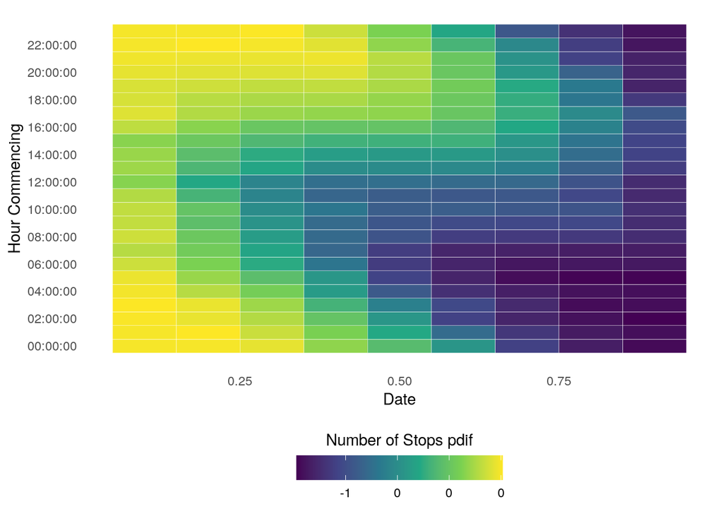

### 0.4.2 Urbanicity

The urbanicity of a person’s home might also impact the cutoff point decision. Persons living in more rural areas are more likely to make longer trips, which may allow for a longer gap time before significant data losses are incurred.

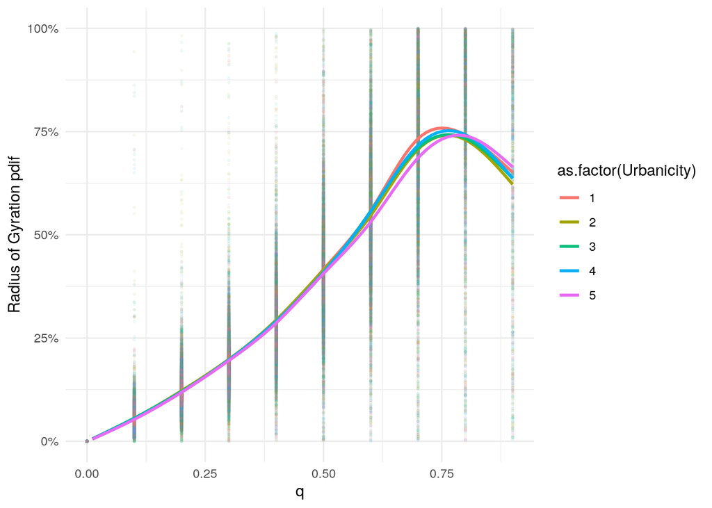

Figure 1: Radius

### 0.4.3 Age

The age of a participant may impact the tendency towards certain travel behaviors.

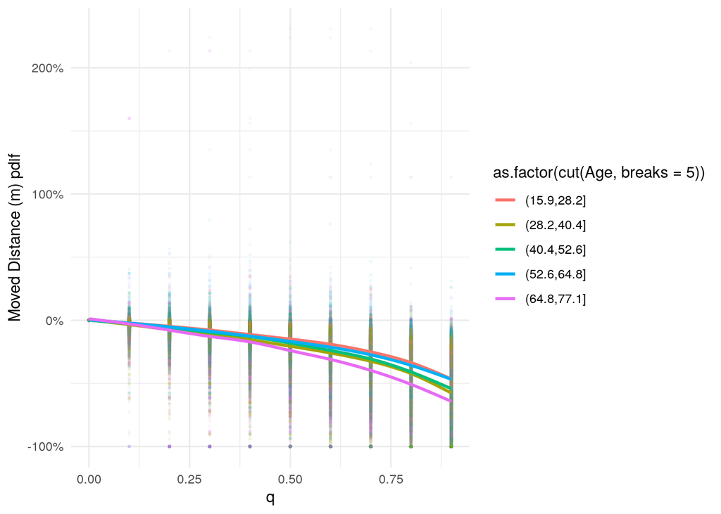

Figure 2: Age

## 0.5 Appendix

Full table MCAR

Short gap simulation study

|  | mean (sd) abs | mean (sd) perc | median abs | median perc |
| --- | --- | --- | --- | --- |
| Delta Total Distance (m) |  |  |  |  |
| 0.1 | −1.2K (2.4K) | −2.8% (4.0%) | −575.0 | −1.7% |
| 0.2 | −2.6K (3.9K) | −6.1% (6.4%) | −1.4K | −4.4% |
| 0.3 | −4.1K (5.6K) | −9.5% (8.3%) | −2.4K | −7.5% |
| 0.4 | −5.8K (7.6K) | −13.2% (10.1%) | −3.4K | −10.8% |
| 0.5 | −7.7K (9.3K) | −17.7% (12.3%) | −4.8K | −14.7% |
| 0.6 | −9.9K (11.7K) | −22.3% (14.2%) | −6.2K | −18.9% |
| 0.7 | −12.5K (14.4K) | −27.9% (16.4%) | −7.8K | −23.9% |
| 0.8 | −16.2K (18.8K) | −35.5% (19.4%) | −10.0K | −30.7% |
| 0.9 | −22.1K (26.4K) | −46.5% (22.9%) | −13.1K | −41.8% |
| Delta Moved Distance (m) |  |  |  |  |
| 0.1 | −1.0K (2.0K) | −2.7% (7.3%) | −368.8 | −1.2% |
| 0.2 | −2.2K (3.6K) | −6.3% (10.9%) | −1.1K | −3.8% |
| 0.3 | −3.5K (5.2K) | −10.1% (14.1%) | −1.8K | −6.9% |
| 0.4 | −5.0K (7.0K) | −13.8% (16.2%) | −2.6K | −10.2% |
| 0.5 | −6.7K (8.8K) | −19.0% (18.8%) | −3.8K | −14.2% |
| 0.6 | −8.7K (11.1K) | −24.2% (21.2%) | −4.9K | −18.4% |
| 0.7 | −11.1K (13.8K) | −31.0% (23.8%) | −6.5K | −24.0% |
| 0.8 | −14.6K (18.2K) | −40.4% (26.7%) | −8.5K | −31.7% |
| 0.9 | −20.4K (25.6K) | −54.0% (29.5%) | −11.9K | −47.7% |
| Delta Number of Stops |  |  |  |  |
| 0.1 | −0.1 (0.6) | −1.6% (8.0%) | 0.0 | 0.0% |
| 0.2 | −0.3 (0.8) | −3.6% (11.3%) | 0.0 | 0.0% |
| 0.3 | −0.5 (1.1) | −5.9% (14.4%) | 0.0 | 0.0% |
| 0.4 | −0.7 (1.3) | −8.4% (16.3%) | 0.0 | 0.0% |
| 0.5 | −1.0 (1.6) | −11.6% (18.5%) | −1.0 | −9.1% |
| 0.6 | −1.3 (1.9) | −15.7% (20.8%) | −1.0 | −16.7% |
| 0.7 | −1.7 (2.2) | −21.0% (22.5%) | −1.0 | −20.0% |
| 0.8 | −2.2 (2.7) | −28.4% (24.6%) | −2.0 | −30.0% |
| 0.9 | −3.0 (3.2) | −40.4% (25.7%) | −2.0 | −43.7% |
| Delta Number of Moves |  |  |  |  |
| 0.1 | −0.1 (0.5) | −1.8% (10.5%) | 0.0 | 0.0% |
| 0.2 | −0.3 (0.8) | −4.5% (14.7%) | 0.0 | 0.0% |
| 0.3 | −0.5 (1.1) | −7.6% (18.7%) | 0.0 | 0.0% |
| 0.4 | −0.8 (1.3) | −11.4% (20.5%) | 0.0 | 0.0% |
| 0.5 | −1.1 (1.6) | −16.7% (23.0%) | −1.0 | −14.3% |
| 0.6 | −1.5 (1.9) | −22.9% (25.1%) | −1.0 | −22.2% |
| 0.7 | −1.9 (2.3) | −31.2% (27.0%) | −1.0 | −33.3% |
| 0.8 | −2.6 (2.7) | −42.2% (28.7%) | −2.0 | −42.9% |
| 0.9 | −3.4 (3.2) | −58.3% (29.1%) | −3.0 | −60.0% |
| Delta Mean SD latitude |  |  |  |  |
| 0.1 | 0.0 (0.0) | 4.0% (30.6%) | 0.0 | 1.1% |
| 0.2 | 0.0 (0.0) | 10.5% (52.8%) | 0.0 | 2.9% |
| 0.3 | 0.0 (0.0) | 18.4% (68.0%) | 0.0 | 5.6% |
| 0.4 | 0.0 (0.0) | 30.7% (96.6%) | 0.0 | 9.4% |
| 0.5 | 0.0 (0.0) | 52.2% (139.2%) | 0.0 | 16.5% |
| 0.6 | 0.0 (0.0) | 80.9% (178.7%) | 0.0 | 28.4% |
| 0.7 | 0.0 (0.0) | 135.1% (268.4%) | 0.0 | 49.8% |
| 0.8 | 0.0 (0.0) | 239.6% (425.0%) | 0.0 | 95.6% |
| 0.9 | 0.0 (0.0) | 536.8% (938.5%) | 0.0 | 186.6% |
| Delta Mean SD longitude |  |  |  |  |
| 0.1 | −0.0 (0.0) | 4.2% (30.7%) | 0.0 | 1.2% |
| 0.2 | −0.0 (0.0) | 9.4% (44.1%) | 0.0 | 3.0% |
| 0.3 | −0.0 (0.0) | 17.1% (57.7%) | 0.0 | 5.8% |
| 0.4 | −0.0 (0.0) | 29.7% (92.8%) | 0.0 | 10.1% |
| 0.5 | 0.0 (0.0) | 49.1% (118.0%) | 0.0 | 18.5% |
| 0.6 | 0.0 (0.0) | 79.9% (171.8%) | 0.0 | 31.1% |
| 0.7 | 0.0 (0.0) | 138.0% (273.2%) | 0.0 | 54.2% |
| 0.8 | 0.0 (0.0) | 238.1% (420.9%) | 0.0 | 96.1% |
| 0.9 | 0.0 (0.0) | 537.4% (970.8%) | 0.0 | 180.2% |
| Delta Number of locations |  |  |  |  |
| 0.1 | −775.4 (610.8) | −9.6% (4.0%) | −654.0 | −9.2% |
| 0.2 | −1.6K (1.2K) | −19.5% (5.5%) | −1.3K | −19.3% |
| 0.3 | −2.4K (1.7K) | −29.3% (6.2%) | −1.9K | −29.3% |
| 0.4 | −3.2K (2.3K) | −39.1% (6.6%) | −2.6K | −39.2% |
| 0.5 | −4.0K (2.9K) | −49.0% (6.8%) | −3.3K | −49.3% |
| 0.6 | −4.7K (3.4K) | −58.2% (6.7%) | −3.9K | −58.7% |
| 0.7 | −5.5K (4.0K) | −67.7% (6.5%) | −4.5K | −68.4% |
| 0.8 | −6.3K (4.5K) | −77.0% (6.2%) | −5.1K | −78.0% |
| 0.9 | −7.0K (5.1K) | −85.5% (6.2%) | −5.7K | −87.1% |
| Delta Radius of Gyration |  |  |  |  |
| 0.1 | 4.9 (12.6) | 5.6% (15.1%) | 1.2 | 5.0% |
| 0.2 | 10.7 (25.4) | 12.2% (24.5%) | 2.8 | 11.3% |
| 0.3 | 17.8 (43.2) | 22.1% (87.7%) | 4.7 | 18.9% |
| 0.4 | 26.4 (62.7) | 32.2% (97.6%) | 7.1 | 28.1% |
| 0.5 | 36.7 (87.2) | 46.8% (176.8%) | 10.0 | 40.2% |
| 0.6 | 50.3 (120.2) | 66.3% (208.8%) | 13.7 | 55.3% |
| 0.7 | 69.5 (165.2) | 104.3% (427.3%) | 19.1 | 77.5% |
| 0.8 | 97.0 (242.9) | 154.3% (549.5%) | 26.9 | 111.4% |
| 0.9 | 146.2 (366.0) | 267.3% (1,038.3%) | 39.8 | 173.1% |

Full table MCAR

Long gap simulation study

|  | mean (sd) abs | mean (sd) perc | median abs | median perc |
| --- | --- | --- | --- | --- |
| Delta Total Distance (m) |  |  |  |  |
| 0.1 | −3.5K (11.5K) | −4.7% (12.1%) | −9.6 | −0.0% |
| 0.2 | −8.4K (20.0K) | −11.8% (21.7%) | −412.6 | −0.8% |
| 0.3 | −15.1K (30.2K) | −20.2% (28.4%) | −2.1K | −7.1% |
| 0.4 | −23.4K (41.5K) | −29.9% (32.8%) | −5.2K | −15.8% |
| 0.5 | −32.5K (53.2K) | −40.1% (35.8%) | −10.8K | −32.8% |
| 0.6 | −41.5K (62.7K) | −50.9% (37.0%) | −14.1K | −49.6% |
| 0.7 | −52.3K (73.5K) | −62.5% (35.4%) | −24.5K | −65.5% |
| 0.8 | −64.2K (84.4K) | −75.2% (30.9%) | −31.4K | −93.0% |
| 0.9 | −76.0K (94.7K) | −87.7% (22.3%) | −43.0K | −99.7% |
| Delta Moved Distance (m) |  |  |  |  |
| 0.1 | −3.4K (11.3K) | −5.7% (14.5%) | 0.0 | 0.0% |
| 0.2 | −8.3K (19.6K) | −14.2% (25.1%) | 0.0 | 0.0% |
| 0.3 | −15.2K (29.6K) | −24.4% (31.4%) | −2.3K | −8.7% |
| 0.4 | −23.5K (40.8K) | −34.4% (34.3%) | −6.5K | −25.3% |
| 0.5 | −32.3K (52.3K) | −44.8% (36.1%) | −11.0K | −46.0% |
| 0.6 | −40.5K (61.7K) | −55.1% (36.3%) | −17.0K | −52.3% |
| 0.7 | −50.5K (72.5K) | −65.8% (34.2%) | −24.3K | −68.3% |
| 0.8 | −61.6K (83.5K) | −77.8% (29.2%) | −31.9K | −97.3% |
| 0.9 | −72.3K (94.0K) | −89.0% (21.3%) | −38.0K | −100.0% |
| Delta Number of Stops |  |  |  |  |
| 0.1 | −0.3 (0.8) | −4.9% (12.0%) | 0.0 | 0.0% |
| 0.2 | −0.8 (1.3) | −11.2% (18.7%) | 0.0 | 0.0% |
| 0.3 | −1.2 (1.7) | −18.5% (22.7%) | 0.0 | 0.0% |
| 0.4 | −1.7 (2.0) | −26.3% (25.8%) | −1.0 | −25.0% |
| 0.5 | −2.2 (2.2) | −34.3% (27.6%) | −2.0 | −33.3% |
| 0.6 | −2.8 (2.5) | −42.9% (28.2%) | −2.0 | −50.0% |
| 0.7 | −3.4 (2.6) | −52.2% (26.5%) | −3.0 | −54.5% |
| 0.8 | −4.0 (2.7) | −61.6% (23.1%) | −4.0 | −66.7% |
| 0.9 | −4.6 (2.8) | −70.8% (18.1%) | −4.0 | −75.0% |

[output cut: 70 more lines]